# RepResearchCourseProj1

Prashanth Jayaseelan

December 23, 2016

## Data ingest

The below code will download the data and load into R environment

```r
download.file("https://github.com/prashanthjayaseelan/RepData_PeerAssessment1/raw/master/activity.zip",destfile = "activity.zip")
unzip('activity.zip')
activity=read.csv("activity.csv")
```

## Answers to the question ‘What is mean total number of steps taken per day?’

1.Calculation of the total number of steps:

```r
tot=aggregate(activity$steps~activity$date,activity,sum)
```

2.Histogram of the total number of steps:

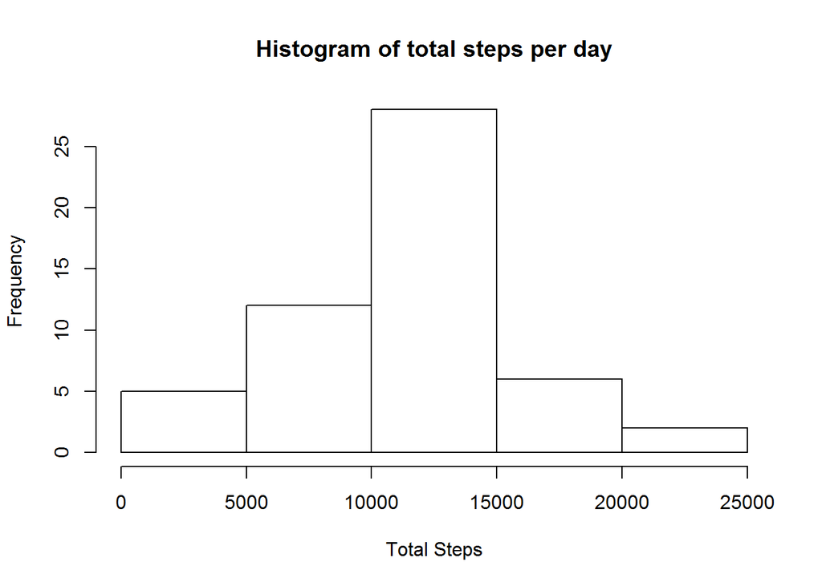

```r
tot$date=strptime(tot$`activity$date`,"%Y-%m-%d")
hist(tot$`activity$steps`, xlab="Total Steps", main = "Histogram of total steps per day")
```

```r
meanperday=mean(tot$`activity$steps`,na.rm = TRUE)
medianperday=median(tot$`activity$steps`,na.rm=TRUE)
```

## Answer to the question ‘What is the average daily activity pattern?’

1. Make a time series plot (i.e. type = “l”) of the 5-minute interval (x-axis) and the average number of steps taken, averaged across all days (y-axis)

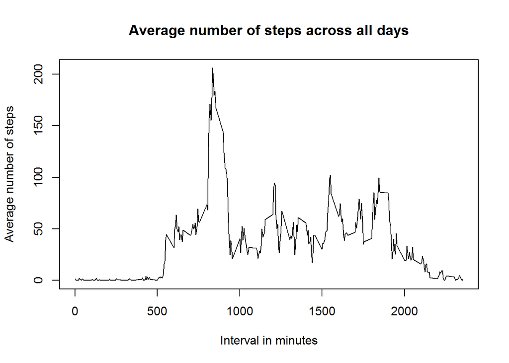

```r
actavg=aggregate(activity$steps~activity$interval,activity,mean)
plot(actavg$`activity$interval`,actavg$`activity$steps`,type="l", xlab="Interval in minutes",
     ylab="Average number of steps", main="Average number of steps across all days")
```

2.Which 5-minute interval, on average across all the days in the dataset, contains the maximum number of steps?

```r
maxsteps = which(actavg$`activity$steps`==max(actavg$`activity$steps`))
maxint = actavg[maxsteps,1]
```

The result is 835